# Variáveis Aleatórias Contínuas:

## Objetivos

## Trataremos dos temas:

## Revisão do Modelo Normal

## Distribuição Normal

- O modelo normal é um dos mais importantes modelos probabilísticos,
- Aplicado em inúmeros fenômenos, naturais ou artificiais, e constantemente utilizado para desenvolvimento teórico da inferência estatística, este modelo é definido pela **Distribuição Normal**.

  Fenômeno natural
- Seja o experimento, selecionar um recém-nascido ao acaso, em uma população, e observar o perímetro cefálico.

Fenômeno artificial

- Considere o experimento que consite em comprar uma garrafa de água mineral e verificar seu volume, o qual deve ser de 300 ml.

## Distribuição Normal

- O modelo normal é um dos mais importantes modelos probabilísticos,
- Aplicado em inúmeros fenômenos, naturais ou artificiais, e constantemente utilizado para desenvolvimento teórico da inferência estatística, este modelo é definido pela **Distribuição Normal**.

Fenômeno natural

- Seja o experimento, selecionar um recém-nascido ao acaso, em uma população, e observar o perímetro cefálico.

Fenômeno artificial

- Considere o experimento que consite em comprar uma garrafa de água mineral e verificar seu volume, o qual deve ser de 300 ml.

Uma variável aleatória \(X\) segue uma distribuição normal com parâmetros \(\mu\) e \(\sigma^2\), se sua função densidade é dada por:

\(f(x)=\frac{1}{\sqrt{2\pi\sigma^2}} e^{-\frac{1}{2\sigma^2}(x-\mu)^2}, \mbox{ para todo } x \in \mathbb{R}\),

em que \(-\infty< \mu <\infty\) e \(\sigma>0\).

- Notação: \(X \sim N(\mu, \sigma^2)\).

## Gráfico da distribuição normal

Curva da função \(f(x)=\frac{1}{\sqrt{2\pi\sigma^2}} e^{-\frac{1}{2\sigma^2}(x-\mu)^2}\)

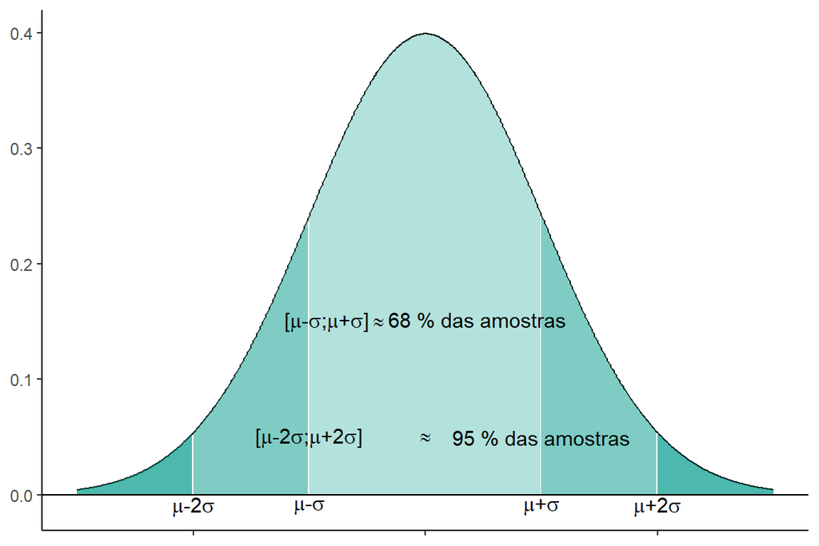

a curva da densidade da distribuição normal, \(f(x)\), tem forma de sino, de modo que:

1. \(f(x)\) atinge seu máximo em \(\mu\);
2. a curva de \(f(x)\) é simétrica em relação a \(\mu\);
3. \(\mu- \sigma\) e \(\mu+ \sigma\) são pontos de inflexão de \(f(x)\);
4. \(E(X)= \mu\);
5. \(Var(X)= \sigma^2\) então \(DP= \sigma\);
6. O desvio-padrão \(\sigma\) e a média \(\mu\) são diretamente parâmetros da distribuição.

## Distribuição Normal Padrão

- A distribuição normal padrão é aquela em que a média da distribuição é 0 e a variâmcia é 1.
- Notação: \(Y \sim N(0,1)\).
- Sua densidade é aquela apresentada anteriormente, fixando \(\mu=0\) e \(\sigma^2=1\).
- Ou seja, \(f(y)=\frac{1}{\sqrt{2\pi}} e^{-\frac{y^2}{2}}, \mbox{ para todo } y \in \mathbb{R}.\)
- A FDA da distribuição normal padrão é normalmente denotada por \(\Phi(x)\), sendo, então, dada por:

\(\Phi(y)=P(Y\leq y)=\int_{-\infty}^{y}\frac{1}{\sqrt{2\pi}} e^{-\frac{x^2}{2}} dx, \mbox{ para todo } y \in \mathbb{R}\).

- O nome “Normal Padrão” é justificado pela obtenção da distribuição \(N(0,1)\) a partir da variável transformada:

\[Z=\frac{Y-\mu}{\sigma},\]

em que \(Y \sim N(\mu, \sigma^2).\)

- Como \(Z\) é uma transformação de uma variável normal, \(Z\) também tem distribuição normal, e sua média e variância são dadas por:

\(E[Z]=E[\frac{Y-\mu}{\sigma}]= \frac{E[Y]-\mu}{\sigma}=\frac{\mu-\mu}{\sigma}=0\)

\(Var[Z]=Var(\frac{Y-\mu}{\sigma})=\frac{Var[Y]}{\sigma^2}=\frac{\sigma^2}{\sigma}=1.\)

- Ou seja, \(E[Z]=0\) e \(Var(Z)=1\).
- Deste modo, a variável padrozinada obdedece: \(Z \sim N(0,1)\).

## Probabilidades normais

- Os principais valores de probabilidades da distribuição normal padrão podem ser encontrados em tabelas.
- Usando essas tabelas, aplicativos ou softwares, podemos obter os valores de probabilidades para qualquer distribuição normal, como segue:

  \[Z=\frac{Y-\mu}{\sigma} \Longrightarrow \ \ \ \ P(Y\leq a)=P\left(\dfrac{Y-\mu}{\sigma}\leq \dfrac{a-\mu}{\sigma} \right)= P(Z \leq \frac{a-\mu}{\sigma}), \] essa última igualdade pode ser resolvida por aproximação usando uma tabela de probabilidades normais.

## Exemplo de revisão

Uma enchedora automática de garrafas de água está regulada para que o volume médio de líquido em cada garrafa seja de 1000 \(cm^3\) e desvio padrão de 10 \(cm^3\). Admita que o volume siga uma distribuição normal.

1. Qual é a porcentagem de garrafas em que o volume de líquido é menor que 990 \(cm^3\)?
2. Qual é a porcentagem de garrafas em que o volume de líquido não se desvia da média em mais do que dois desvios padrões?
3. Se 10 garrafas são selecionadas ao acaso, qual é a probabilidade de que, no máximo, 3 tenham volume de líquido superior a 1002 \(cm^3\)?
4. Qual a probabilidade da média amostral, com dez retiradas ao acaso, se desviar da média verdadeira em mais ou menos um desvio-padrão?

## Inferência

## População e Amostra

- O objetivo da inferência estatística é obter informações sobre populações, sem que para isto seja necessário acessar todos os seus elementos.
- Ou seja, as informações são obtidas com base em **amostras**.
- Se a população é homogênea, em termos da característica investigada, qualquer amostra pode ser utilizada no processo de inferência.

**Exemplo 1:** Para obter informações sobre o nível de glicose no sangue de uma pessoa, basta uma amostra bem pequena do seu sangue.

**Exemplo 2:** Para checar se um prato foi preparado com as medidas certas de tempero, basta provar uma pequena porção.

- **População:** conjunto de elementos com pelo menos uma caracteristica em comum que a delimita, sendo este conjunto o objeto alvo do estudo.
- **Amostra representativa da população:** subconjunto da população capaz de representar a população como um todo, no que diz respeito a(s) característica(s) investigada(s).
- **Amostra probabilística:** amostra que permite a realização da inferência estatística acerca dessas características.
- **amostragem probabilística:** consiste no processo de selecionar elementos (ou conjunto de elementos) de uma população bem definida, usando um procedimento capaz de atribuir a cada elemento (ou conjunto de elementos) da população uma probabilidade do mesmo ser selecionado, sendo essa probabilidade calculável e diferente de zero.

## Variável e Amostra Aleatória Simples

Os elementos de uma população podem ser entendidos como entidades portadoras das informações que pretende-se coletar (fenômenos, pessoas, máquinas, estabelecimentos comerciais etc.).

- **Variáveis:** são as características associadas a essas entidades, as quais queremos investigar.
- Em geral queremos estudar a frequência de ocorrência das variáveis.
- Para isto, é utilizada uma **amostra aleatória** e um **modelo probabilístico**.

Uma **amostra aleatória simples** de tamanho \(n\) de uma única variável aleatória \(X\) (com distribuição dada por \(F(x)\)) é um vetor \[{\bf X} = (X_1, X _2, \cdots,X_n)\] em que cada componente \(X_1 X _2, \cdots,X_n\) tem a mesma distribuição de \(X\).

- Toda informação que desejamos obter sobre uma população é obtida, se conhecemos completamente a distribuição de probabilidades da variável \(X\) considerada.

## Exemplo

- **População:** itens produzidos por uma determinada máquina;
- **Característica em comum:** produzidos pela mesma máquina;
- **Característica de interesse:** qualidade da peça;
- **X**: defeito \(\longrightarrow\) 1, não defeito\(\longrightarrow\) 0.
- Então, \(X\) representa o estado de TODAS as peças produzidas pela máquina, com ou sem defeito, que já foram ou que ainda serão produzidas.
- Neste caso temos: \(X \sim Bernoulli(p)\), com \(p\) desconhecido, devendo ser estimado.

## Etapas da análise inferencial

- Em geral, não se pode ter certeza sobre a distribuição de \(X\), e nem sobre seus parâmetros.
- Assim, a partir de uma análise exploratória dos dados, é proposto um modelo probabilístico.
- A amostra é utilizada para estimar os seus parâmetros.
- Por fim, testes estatístico são realizados para checar a adequação do modelo proposto.

**Observação:**

- os métodos de inferência discutidos aqui são baseados na obteção de uma **amostra aleatória simples**,
- chamada aqui de **amostra aleatória**.

## Parâmetro e Estatística

**Parâmetro:** qualquer característica da população.

- Exmplo:
  - média populacional (\(\mu\));
  - variância populacional (\(\sigma^2\));
  - proporção populacional (\(p\));
  - tamanho da população (\(N\));
  - taxa de ocorrência de algum fenômeno na população (\(\lambda\)).

**Estatística:** qualquer função da amostra

- Exmplo:
  - média amostral (\(\overline{X}\));
  - variância amostral (\(S^2\));
  - proporção amostral (\(P\));
  - tamanho da amostra (\(n\));
  - taxa de ocorrência de algum fenômeno na amostra (\(\frac{n_A}{n}\)), em que \(n_A\) é a quatidade de vezes que ocorre o fenômeno na amostra.

## Exemplo

Supondo \(X_1,X_2\) amostra aleatória simples da variável aleatória \(X\) tal que \[X \sim Bernoulli(p),\]

- Se uma amostra aleatória de tamanho \(n=2\) é estraída, tem-se:
  - \(X_1 \sim Bernoulli(p)\), primeira seleção;
  - \(X_2 \sim Bernoulli(p)\), segunda seleção.
- Assim,

\[T(X_1,X_2)=X_1+X_2\]

é uma estatística.

**Observações**

- Qualquer função apenas da amostra (fórmula ou expressão) é uma **estatística**.
- As estatísticas são utilizadas para estimar os parâmetros.
- Estatísticas com boas propriedades são utilizadas para estimar parâmetros, e ganham o nome de **estimador**.

## Estimação Pontual

## Estimador e Estimativa

Considere que uma amostra aleatória \({\bf X} = (X_1, X_2, \cdots, X_n)\) seja selecionada.

Então, a partir dessa amostra, se uma estatística \[T({\bf X}) = T(X_1, X_2, \cdots, X_n)\] é usada para estimar um parâmetro, então essa estatística é chamada de **ESTIMADOR**.

Chamamos de **ESTIMATIVA**, o valor assumido pelo estimador \[T({\bf x} ) = T(x_1, x_2, \cdots, x_n)\] depois de serem observados \((x_1, x _2, \cdots,x_n)\) a partir de \((X_1, X _2, \cdots,X_n)\).

**Exemplo:** Considere o problema de quermos estimar a proporção de defeitos produzidos por uma máquina. Assim, define-se a vvariável aleatória:

\[ X= \left\{ \begin{array}{ll} 1,&~~ \text{se uma peça selecionada tem defeito} \\ 0, &~~ \text{se uma peça selecionada não tem defeito}.\\ \end{array} \right. \] Assim, \(X \sim Bernoulli(p)\), com \(p\) desconhecido.

Supondo que duas peças sejam selecionadas de forma aleatória, então tem-se \(X_1,X_2\) tais que:

- \(X_1 \sim Bernoulli(p)\) e
- \(X_2 \sim Bernoulli(p)\).

Então, se \(\hat{p}=T(X_1,X_2)=\bar{X}=\frac{X_1+X_2}{2}\) é um estimator para \(p\) e observarmos \(x_1=0\) e \(x_2=1\),

\(\hat{p}=\frac{x_1+x_2}{2}=\frac{0+1}{2}=1/2\) é uma estimativa de \(p\).

## Exemplos de estimadores utilizados na prática

- A **média amostral**: \(\overline{X}=\frac{1}{n}\sum_{i=1}^{n}X_i\)

é um estimador para a média populacional \(\mu\).

- A **variância amostral**:  
  \(S^2=\frac{\sum_{i=1}^{n}(X_i-\overline{X})}{n-1}\)

é um estimador para variância populacional \(\sigma^2\).

- A **proporção amostral**: \(\hat{p}=\frac{X}{n}\),
  - em que \(X\) é o número de elementos na amostra e
  - \(n\) é o tamanho da amostra,

é um estimador da proporção populacional \(p\).

- Em geral, denotamos os parâmetros desconhecidos por uma letra grega.
- Exemplo, \(\theta, \lambda, \eta, \delta\) etc.
- e as suas estimativas pelas respectivas letras com ” ^”
- Exemplo \(\hat{\theta}, \hat{\lambda}, \hat{\eta}, \hat{\delta}\) etc.
- Como exceções citamos os estimadores para média e e variância \((\mu, \sigma^2)\), que são denotados de forma diferente \((\bar{X}, S^2)\).

## Distribuição Amostral

## Distribuição do estimador

- Como estimadores são estatísticas, estes são funções de variáveis aleatórias, \(T=T({\bf X})\),
- então estes também são variáveis aleatórias,
- logo possuem uma distribuição de probabilidades.
- Essa distribuição é chamada de **distribuição amostral** do estimador.
- Com isso, faz sentido falarmos de média \(E(T)\) e de variância \(Var(T)\) de um estimador \(T\).

## Exemplo

No exemplo anterior, consideramos duas peças selecionadas de forma aleatória, dando origem a \(X_1,X_2\) tais que:

- \(X_1 \sim Bernoulli(p)\) e
- \(X_2 \sim Bernoulli(p)\).

Além disso, temos que \(\hat{p}=\frac{X_1+X_2}{2}\) é um estimator para \(p\).

A esperança de \(\hat{p}\) é dada por: \[E(\hat{p})=\frac{E(X_1+X_2)}{2}=\frac{E(X_1)+E(X_2)}{2}=\frac{p+p}{2}=p.\]

- Note que a esperança do estimador \(\hat{p}\) é igual ao parâmetro \(p\).
- Isso confere ao estimador \(\hat{p}\) uma importante propriedade.
- Uma vez que, obtendo-se várias amostras aleatórias de mesmo tamanho,
- a média desses valores deverá estar próxima do valor verdadeiro do parâmetro a ser estimado.

## Propriedades dos Estimadores

## Vício de um estimador

1. Um estimador \(T = T(X_1, X_2, \cdots, X_n)\) é dito não viciado (não enviesado), para o parâmetro \(\theta\), se sua esperança é igual ao parâmetro, ou seja \[\mathbb{E}(T)=\theta,\] para todo \(\theta\).
2. Se a igualdade acima não ocorre, dizemos que \(T\) é um estimador viciado (viesado) e a diferença \(V(T,\theta) = \mathbb{E}(T) - \theta\) é chamada de vício (viés) do estimador \(T\).

**Exemplos**

A média amostral \(\overline{X}=\frac{\sum_{i=1}^{n}X_i}{n}\) é não viciada para estimar a média populacional:

- \(\mathbb{E}(\overline{X})=\mu.\)

A variância amostral \(S^2=\frac{\sum_{i=1}^{n}(X_i-\overline{X})}{n-1}\) é não viciada para estimar a variânacia populacional:

- \(\mathbb{E}(S^2)=\sigma^2\).

A proporção amostral \(\hat{P}=\frac{Y}{n}\), com \(Y=\sum_{i=1}^{n}X_i\), definida a partir de \(n\) ensaios independentes de Bernoulli, é não viciada para estimar a proporção populacional:

- \(\mathbb{E}(\hat{P})=p.\)

## Precisão do estimador

- Além da esperança, pode ser calculada a variância dos estimadores apresentados anteriormente.
- Na prática, é desejado que o esetimador utilizado seja aquele com ménor variância.
- Pode ser mostrado que os estimadores apresentados anteriormente são os de menor variância para estimar os parâmetros considerados.
- O máximo que pode ocorrer é exitir estimadares com variância igual as que apresetam esses estimadores, mas nunca maior.
- Portanto, estes estimadores são os melhores, para estimar os respectivos parâmetros.

A média amostral \(\overline{X}=\frac{\sum_{i=1}^{n}X_i}{n}\) tem a menor (ou igual) variância entre aqueles estimadores usados para estimar a média populacional:

- \(\mathbb{Var}(\overline{X})= \frac{\sigma^2}{n}\)

A variância amostral \(S^2=\frac{\sum_{i=1}^{n}(X_i-\overline{X})}{n-1}\) tem a menor (ou igual) variância entre aqueles usados para estimar a variânacia populacional:

- \(\mathbb{Var}(S^2)=\frac{2\sigma^4}{n-1}\).

A proporção amostral \(\hat{P}=\frac{Y}{n}\), com \(Y=\sum_{i=1}^{n}X_i\), definida a partir de \(n\) ensaios independentes de Bernoulli, tem a menor (ou igual) variância entre aqueles usados para estimar a proporção populacional:

- \(\mathbb{Var}(\hat{P})=\frac{p(1-p)}{n}.\)

## Distribuição Amostral a Média

## Teorema do Limite Central (TLC)

- Em uma amostra aleatória simples de tamanho \(n\), \({\bf X}=(X_1,X_2,\cdots,X_n)\), de uma população qualquer, representada por \(X\), com média \(\mu\) e variância \(\sigma^2\),
- a distribuição de \(\overline{X}\) é aproximadamente normal com média \(\mu\) e variância \(\frac{\sigma^2}{n}\),
- ou seja,

  \[\mbox{se } n \rightarrow \infty \mbox{ então } \overline{X} \rightarrow N(\mu,\frac{\sigma^2}{n}),\]

em que \(N(\mu,\frac{\sigma^2}{n})\) representa a distribuição normal de média \(\mu\) e variância \(\frac{\sigma^2}{n}\).

- Neste resultado, se incluirmos a suposição de que X tem distribuição normal, ou seja,

  \[X \sim N(\mu,\sigma^2), \]
- Então a distribuição de \(\overline{X}\) é exatamente normal, ou seja

  \[\overline{X} \sim N\left( \mu,\frac{\sigma^2}{n}\right).\]

Obs: reveja o Exemplo visto no início do tópico, sobre volumes de garrafas com água.

## Exemplo

- Suponha que numa fazenda de camarões existam 50 berçários.
- O carcinicultor recebe as larvas do fornecedor e as divide entre os berçários.
- Considerando que a quantidade de larvas tendem a diminuir, devido a morte precoce, o carcinicultor tem interesse em estimar a quantidade média de larvas nos berçários após um determinado tempo.
- Considerando que as larvas têm a mesma procedência e recebem o mesmo tratamento, o carcinicultor concluí que basta selecionar 4 berçários de forma aleatória e contar a quantidade de larvas, para se ter uma ideia da quantidade média de larvas nos berçários.

Suponha que cada berçário contenha, na realidade, as seguintes quantidades de larvas.

[output not shown]

- É possível que o carcinicultor obtenha uma boa estimativa?
- Vamos simular a extração de amostras aleatórias de tamanho 4 a partir desta população!

## Histograma real da população

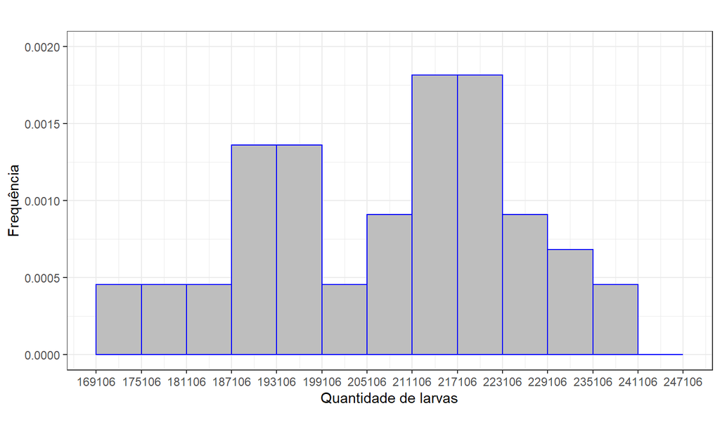

```
## [1] 208265.4
```

## Simulação de amostras de vários tamanhos

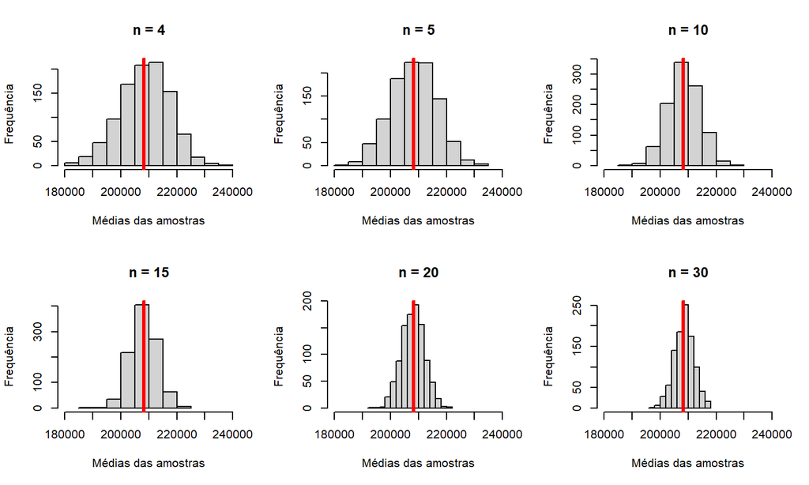

## Exemplo

Um elevador tem seu funcionamento bloqueado se sua carga for superior a 450 kg. Sabes-e que o peso de um adulto é uma variável aleatória com distribuição normal, sendo a média igual a 65 kg e o desvio igual a 15 kg.

1. Qual a probabilidade de ocorrer o bloqueio numa tentativa de transportar 7 adultos?
2. Encontre um intervalo que contenha 90% das médias amostrais, quando são realizadas tentativas de transportar 7 pessoas no elevador.